# Variation of absorption with concentration of dye

W. Bauer

August 24, 2015

This note shows that total absorption varies linearly with concentration for concentrations of dye in the range of .67 to 5 $\mu$molar. The foveal region of area 17 was stained with concentrations in that range and total absorption in that region recorded after 5000 simulation steps (10 nanoseconds,) the amount required for saturation. Runs were done prior to writing this note using `Scripts/concentrationRuns.R`.

Here, *concentration* refers to the total amount of dye in a volume. How that dye might be distributed between neural membranes, glial membranes, interstitial fluid, the vascular bed and so on, isn’t addressed.

The following plot shows the linear relationship. Since units are relative, absorption is shown as multiples of absorption at 1 $\mu$molar.

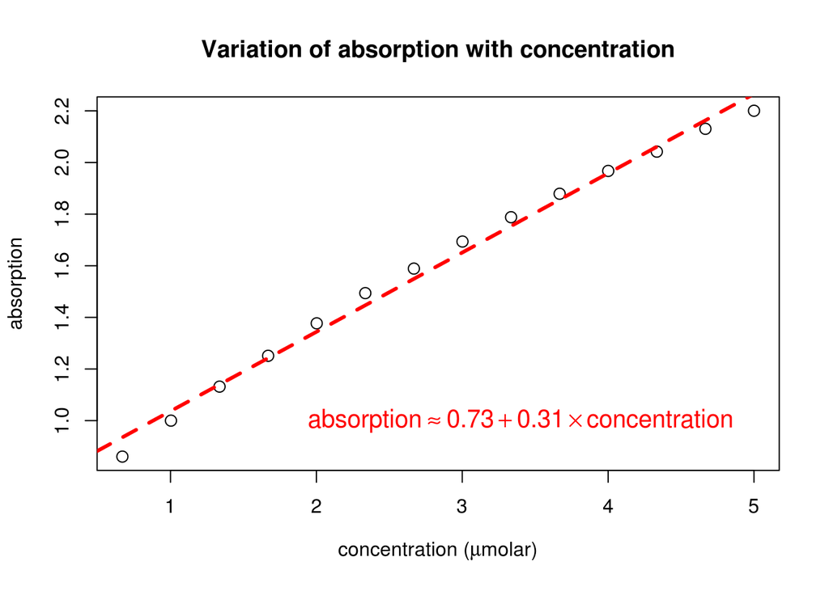

It is clear there is some concavity, and presumably more beyond this limited range, but the R<sup>2</sup> for the red line is 99% within this range.

```
##
## Call:
## lm(formula = absorption ~ concentration, data = rundata)
##
## Residuals:
##       Min        1Q    Median        3Q       Max
## -0.074578 -0.029151  0.008945  0.033820  0.047133
##
## Coefficients:
##               Estimate Std. Error t value Pr(>|t|)
## (Intercept)   0.729455   0.026232   27.81 2.89e-12 ***
## concentration 0.307208   0.008362   36.74 1.06e-13 ***
## ---
## Signif. codes:  0 '***' 0.001 '**' 0.01 '*' 0.05 '.' 0.1 ' ' 1
##
## Residual standard error: 0.04201 on 12 degrees of freedom
## Multiple R-squared:  0.9912, Adjusted R-squared:  0.9905
## F-statistic:  1350 on 1 and 12 DF,  p-value: 1.061e-13
```

The rate of photon absorption in a voxel varies linearly with its absorption coefficient. For many dyes, the aborption coefficient varies linearly with membrane potential or other indicators of neuronal activity. Thus, there is a linear relationship between absorption and neuronal activity in a stained region.